# STATS 506

Problem Set 3

Author

Sky Shi

Modified

October 10, 2024

The link to the problem set 3 GitHub repository is at: https://github.com/skyshi1/STAT506/tree/main/problemSet3, as a sub-folder of the STATS 506 repository.

## Problem 1 - Vision

### (a) Download and merge files

I am using knitr::kable for making the tables. For instructions and helps, I am finding them from https://bookdown.org/yihui/rmarkdown-cookbook/kable.html. For broom, I am following this short note https://cran.r-project.org/web/packages/broom/vignettes/broom.html. And for reading .XPT files, I am using the website https://haven.tidyverse.org/reference/read_xpt.html. The files are already downloaded and put in the same folder as this .qmd file.

```r
# Load necessary libraries
library(dplyr)
library(knitr)  # For making tables
library(kableExtra)  # For making tables look better
library(broom)
library(haven)  # For reading .XPT files

# Import VIX_D and DEMO_D datasets (files are in the working directory)
vix_data <- read_xpt("VIX_D.XPT")
demo_data <- read_xpt("DEMO_D.XPT")

# Inspect the structure of both datasets if needed (commented out for now due to large output)
# str(vix_data)
# str(demo_data)

# Ensure SEQN (Subject ID) is of the same data type in both datasets before merging
vix_data$SEQN <- as.numeric(vix_data$SEQN)
demo_data$SEQN <- as.numeric(demo_data$SEQN)

# Identify the common SEQN values present in both datasets
common_seqn <- intersect(vix_data$SEQN, demo_data$SEQN)

# Merge the datasets based on SEQN, keeping only records that match in both datasets
merged_data <- merge(vix_data, demo_data, by = "SEQN", all = FALSE)

# Perform a sanity check to verify the number of records after merging
sample_size <- nrow(merged_data)
print(paste("Sample size after merging:", sample_size))  # Expected sample size: 6,980
```

```
[1] "Sample size after merging: 6980"
```

The total sample size is 6980, as wanted.

### (b) Estimate the proportion of respondents

```r
# Create age groups in 10-year intervals (e.g., 0-9, 10-19, etc.)
# This helps group respondents by their age ranges
merged_data <- merged_data %>%
  mutate(age_group = cut(RIDAGEYR, breaks = seq(0, 100, by = 10), right = FALSE))

# Calculate the proportion of respondents wearing glasses or contacts for distance vision (VIQ220 == 1) in each age group
# Use summarise to get the proportion in each age group, rounding to 3 decimal places
proportion_table <- merged_data %>%
  group_by(age_group) %>%
  summarise(prop_glasses = round(mean(VIQ220 == 1, na.rm = TRUE), 3))

# Adjust column names for better clarity in the table
colnames(proportion_table) <- c("Age Group", "Proportion")

# Display the proportion table with improved styling using kable and kableExtra
# Styling the table to make it look nicer and more readable
kable(proportion_table, format = "html",
      caption = "Proportion of Respondents Wearing Glasses/Contacts by Age Group") %>%
  kable_styling(bootstrap_options = c("striped", "hover", "condensed"), full_width = F) %>%
  column_spec(1, bold = TRUE) %>%  # Make the "Age Group" column bold for emphasis
  row_spec(0, bold = TRUE, background = "#D3D3D3")  # Add styling to the header row (bold and light grey background)
```

Proportion of Respondents Wearing Glasses/Contacts by Age Group

| Age Group | Proportion |
| --- | --- |
| [10,20) | 0.321 |
| [20,30) | 0.326 |
| [30,40) | 0.359 |
| [40,50) | 0.370 |
| [50,60) | 0.550 |
| [60,70) | 0.622 |
| [70,80) | 0.669 |
| [80,90) | 0.669 |

### (c) Produce a table presenting the estimated odds ratios

```r
# Filter to keep only relevant data where VIQ220 indicates wearing glasses or contacts (1 or 2)
# Recoding VIQ220 so that 1 = Yes (wears glasses/contacts), 0 = No (does not wear glasses/contacts)
merged_data <- merged_data %>%
  filter(VIQ220 %in% c(1, 2)) %>%
  mutate(VIQ220 = ifelse(VIQ220 == 1, 1, 0))  # Recode 1 as "wears" and 2 as "does not wear"

# Logistic regression models
# Model 1: Predicts wearing glasses/contacts based on age (RIDAGEYR)
model1 <- glm(VIQ220 ~ RIDAGEYR, data = merged_data, family = binomial())

# Model 2: Predicts wearing glasses/contacts based on age, race/ethnicity (RIDRETH1), and gender (RIAGENDR)
model2 <- glm(VIQ220 ~ RIDAGEYR + RIDRETH1 + RIAGENDR, data = merged_data, family = binomial())

# Model 3: Adds poverty income ratio (INDFMPIR) to Model 2
model3 <- glm(VIQ220 ~ RIDAGEYR + RIDRETH1 + RIAGENDR + INDFMPIR, data = merged_data, family = binomial())

# Function to calculate McFadden's pseudo-R² for each model
# This gives a measure of model fit (the closer to 1, the better the fit)
pseudo_r2 <- function(model) {
  1 - (logLik(model)[1] / logLik(glm(VIQ220 ~ 1, data = merged_data, family = binomial()))[1])
}

# Calculate AIC and pseudo-R² for each model
aic_model1 <- AIC(model1)
pseudo_r2_model1 <- pseudo_r2(model1)

aic_model2 <- AIC(model2)
pseudo_r2_model2 <- pseudo_r2(model2)

aic_model3 <- AIC(model3)
pseudo_r2_model3 <- pseudo_r2(model3)

# Use broom::tidy to get odds ratios (exponentiated coefficients) and confidence intervals for each model
model1_summary <- tidy(model1, conf.int = TRUE, exponentiate = TRUE)
model2_summary <- tidy(model2, conf.int = TRUE, exponentiate = TRUE)
model3_summary <- tidy(model3, conf.int = TRUE, exponentiate = TRUE)

# Create a summary table with rounded values for easier interpretation
# The table includes Odds Ratios for each predictor and relevant statistics like AIC and Pseudo R²
results <- data.frame(
  Model = c("Model 1: Age Only", "Model 2: Age, Race, Gender", "Model 3: Age, Race, Gender, PIR"),
  `Odds Ratio (Age)` = round(c(model1_summary$estimate[2], model2_summary$estimate[2], model3_summary$estimate[2]), 3),
  `Odds Ratio (Race/Ethnicity)` = round(c(NA, model2_summary$estimate[3], model3_summary$estimate[3]), 3),
  `Odds Ratio (Gender)` = round(c(NA, model2_summary$estimate[4], model3_summary$estimate[4]), 3),
  `Odds Ratio (PIR)` = round(c(NA, NA, model3_summary$estimate[5]), 3),
  `AIC` = round(c(aic_model1, aic_model2, aic_model3), 3),
  `Pseudo R²` = round(c(pseudo_r2_model1, pseudo_r2_model2, pseudo_r2_model3), 3),
  `Sample Size` = c(nobs(model1), nobs(model2), nobs(model3))
)

# Adjust column names for clearer headers
colnames(results) <- c("Model",
                       "Odds Ratio (Age)",
                       "Odds Ratio (Race/Ethnicity)",
                       "Odds Ratio (Gender)",
                       "Odds Ratio (PIR)",
                       "AIC",
                       "Pseudo R²",
                       "Sample Size")

# Display the logistic regression results in a formatted table with kable and kableExtra
kable(results, format = "html",
      caption = "Logistic Regression Results: Predicting Glasses/Contacts Usage") %>%
  kable_styling(bootstrap_options = c("striped", "hover", "condensed"), full_width = F) %>%
  column_spec(1, bold = TRUE) %>%  # Make the "Model" column bold for emphasis
  row_spec(0, bold = TRUE, background = "#D3D3D3")  # Style the header row (bold and grey background)
```

Logistic Regression Results: Predicting Glasses/Contacts Usage

| Model | Odds Ratio (Age) | Odds Ratio (Race/Ethnicity) | Odds Ratio (Gender) | Odds Ratio (PIR) | AIC | Pseudo R² | Sample Size |
| --- | --- | --- | --- | --- | --- | --- | --- |
| Model 1: Age Only | 1.025 | NA | NA | NA | 8475.887 | 0.050 | 6545 |
| Model 2: Age, Race, Gender | 1.025 | 1.133 | 1.646 | NA | 8358.496 | 0.063 | 6545 |
| Model 3: Age, Race, Gender, PIR | 1.024 | 1.097 | 1.680 | 1.153 | 7940.790 | 0.110 | 6247 |

### (d) Test the odds

```r
# Extract the p-value for the gender coefficient from Model 3
model3_summary <- summary(model3)

# Extract p-value for the gender coefficient (RIAGENDR)
p_value_gender <- coef(summary(model3))["RIAGENDR", "Pr(>|z|)"]

# Print the p-value
cat("P-value for Gender Coefficient:", p_value_gender, "\n")
```

```
P-value for Gender Coefficient: 9.508976e-22
```

```r
# Create a contingency table of gender vs. glasses/contact lenses usage (VIQ220)
contingency_table <- table(merged_data$RIAGENDR, merged_data$VIQ220)

# Perform a chi-square test
chi_square_test <- chisq.test(contingency_table)

# Print the chi-square test results
cat("Chi-Square Test Results:\n")
```

```
Chi-Square Test Results:
```

```r
cat("Chi-Square Statistic:", round(chi_square_test$statistic, 3), "\n")
```

```
Chi-Square Statistic: 70.955
```

```r
cat("Degrees of Freedom:", chi_square_test$parameter, "\n")
```

```
Degrees of Freedom: 1
```

```r
cat("P-value for Chi-Square Test:", chi_square_test$p.value, "\n")
```

```
P-value for Chi-Square Test: 3.654119e-17
```

## Problem 2 - Sakila

### (a) Oldest movie

```r
# Load libraries
library(DBI)
library(RSQLite)

# Connect to the SQLite database (make sure to update the path if necessary)
conn <- dbConnect(RSQLite::SQLite(), dbname = "sakila_master.db")

# List all tables to make sure you are not using any tables ending in '_list'
tables <- dbListTables(conn)
tables <- tables[!grepl("_list$", tables)]  # Filter out tables ending in '_list'

# SQL query to find the oldest movie year and count how many movies were released in that year
oldest_movie_query <- "
  SELECT release_year, COUNT(*) AS movie_count
  FROM film
  GROUP BY release_year
  ORDER BY release_year ASC
  LIMIT 1;
"

# Execute the query and fetch the results
oldest_movie_result <- dbGetQuery(conn, oldest_movie_query)

# Display the result
oldest_movie_result
```

```
  release_year movie_count
1         2006        1000
```

The oldest movies are from 2006, with 1000 of them.

### (b) Least common genre

```r
# Approach 1: SQL + R Operations
# Fetching the category and film_category tables using SQL queries and storing them in data frames
category_data <- dbGetQuery(conn, "SELECT * FROM category")
film_category_data <- dbGetQuery(conn, "SELECT * FROM film_category")

# Merge the category and film_category data based on the common category_id column
# This allows us to link films to their genres
genre_data <- merge(category_data, film_category_data, by = "category_id")

# Use R operations to count the number of movies in each genre
# Grouping the data by genre (name) and counting the number of films in each genre
genre_count <- genre_data %>%
  group_by(name) %>%
  summarise(movie_count = n()) %>%
  arrange(movie_count)  # Sort the genres in ascending order of movie count

# Find and display the least common genre using R operations
# The least common genre is the one with the smallest movie count
least_common_genre_r <- genre_count %>%
  slice(1)  # Get the genre with the smallest count
cat("Least common genre using R operations:\n")
```

```
Least common genre using R operations:
```

```r
print(least_common_genre_r)
```

```
# A tibble: 1 × 2
  name  movie_count
  <chr>       <int>
1 Music          51
```

```r
# Approach 2: Single SQL Query
# A SQL query to get the least common genre by directly counting the number of films in each genre
least_common_genre_query <- "
  SELECT c.name AS genre, COUNT(fc.film_id) AS movie_count
  FROM category c
  JOIN film_category fc ON c.category_id = fc.category_id
  GROUP BY c.name
  ORDER BY movie_count ASC
  LIMIT 1;
"
# Run the SQL query and get the result
least_common_genre_result <- dbGetQuery(conn, least_common_genre_query)

# Display the result from the SQL query
cat("Least common genre using SQL query:\n")
```

```
Least common genre using SQL query:
```

```r
print(least_common_genre_result)
```

```
  genre movie_count
1 Music          51
```

So the Music movie is the least common in data, and there are 51 of them.

### (c) Countries with exactly 13 customers

```r
# Approach 1: SQL query to extract data and solve with R operations

# Extract the relevant data from the country, city, address, and customer tables
# These tables contain information about the countries, cities, addresses, and customers
country_data <- dbGetQuery(conn, "SELECT * FROM country")
city_data <- dbGetQuery(conn, "SELECT * FROM city")
address_data <- dbGetQuery(conn, "SELECT * FROM address")
customer_data <- dbGetQuery(conn, "SELECT * FROM customer")

# Merge the tables using R operations to combine country, city, address, and customer information
# Perform successive joins based on the corresponding IDs (country_id, city_id, and address_id)
merged_data <- country_data %>%
  inner_join(city_data, by = "country_id") %>%
  inner_join(address_data, by = "city_id") %>%
  inner_join(customer_data, by = "address_id")

# Group by country and count the number of customers per country
# Then filter for countries that have exactly 13 customers
customer_count_r <- merged_data %>%
  group_by(country) %>%
  summarise(customer_count = n()) %>%
  filter(customer_count == 13)

# Display the result using R operations
# This shows the countries that have exactly 13 customers
customer_count_r
```

```
# A tibble: 2 × 2
  country   customer_count
  <chr>              <int>
1 Argentina             13
2 Nigeria               13
```

```r
# Approach 2: Single SQL query to find countries with exactly 13 customers

# A single SQL query to perform the joins and count customers by country, then filter for those with exactly 13
countries_with_13_customers_query <- "
  SELECT co.country, COUNT(c.customer_id) AS customer_count
  FROM country co
  JOIN city ci ON co.country_id = ci.country_id
  JOIN address a ON ci.city_id = a.city_id
  JOIN customer c ON a.address_id = c.address_id
  GROUP BY co.country
  HAVING customer_count = 13;
"

# Execute the SQL query and store the result
countries_with_13_customers_result <- dbGetQuery(conn, countries_with_13_customers_query)

# Display the result from the SQL query
countries_with_13_customers_result
```

```
    country customer_count
1 Argentina             13
2   Nigeria             13
```

So Argentina and Nigeria have exactly 13 customers.

## Problem 3 - US Records

### (a) Proportion of email addresses with .com

```r
# Load the "US - 500 Records" data from the CSV file
us_records <- read.csv("us-500.csv")

# Extract the email addresses from the dataset
emails <- us_records$email

# Extract the domain part of the email addresses (everything after the '@')
email_domains <- sub(".*@", "", emails)

# Extract the top-level domain (TLD) from each email (everything after the last '.')
email_tlds <- sub(".*\\.", "", email_domains)

# Calculate the proportion of email addresses that have a '.com' TLD
# This checks how many TLDs are '.com' and divides by the total number of emails
proportion_com <- sum(email_tlds == "com") / length(email_tlds)

# Display the proportion of '.com' email addresses
cat("Proportion of email addresses with TLD '.com':", round(proportion_com, 5), "\n")
```

```
Proportion of email addresses with TLD '.com': 0.732
```

### (b) Proportion of email addresses with non alphanumeric character

```r
# Remove '@' and '.' from the email addresses and check for any non-alphanumeric characters
# This helps us focus on characters that aren't part of the usual email format
cleaned_emails <- gsub("[@.]", "", emails)  # Remove "@" and "."

# Count how many email addresses have at least one non-alphanumeric character
# We use grepl() to identify any characters that are not letters or numbers
non_alphanumeric_count <- sum(grepl("[^a-zA-Z0-9]", cleaned_emails))

# Calculate the proportion of email addresses that contain non-alphanumeric characters
proportion_non_alphanumeric <- non_alphanumeric_count / length(emails)

# Display the result, rounding to 5 decimal places for clarity
cat("Proportion of email addresses with non-alphanumeric characters (excluding '@' and '.'):",
    round(proportion_non_alphanumeric, 5), "\n")
```

```
Proportion of email addresses with non-alphanumeric characters (excluding '@' and '.'): 0.248
```

### (c) Top 5 most common area codes

```r
# Extract the phone number column from the dataset
phone_numbers <- us_records$phone1

# Extract the area codes, which are the first 3 digits of the phone numbers
# substr() function is used to get the first three characters from each phone number
area_codes <- substr(phone_numbers, 1, 3)

# Count how many times each area code appears in the dataset
# table() creates a frequency table of area codes
area_code_counts <- table(area_codes)

# Sort the area codes by frequency in descending order and select the top 5 most common area codes
# sort() arranges them in descending order, and we select the first 5 most frequent area codes
top_5_area_codes <- sort(area_code_counts, decreasing = TRUE)[1:5]

# Display the result
cat("Top 5 most common area codes:\n")
```

```
Top 5 most common area codes:
```

```r
print(top_5_area_codes)
```

```
area_codes
973 212 215 410 201
 18  14  14  14  12
```

So the top 5 area codes are 973, 212, 215, 410, 201.

### (d) Log of the apartment numbers

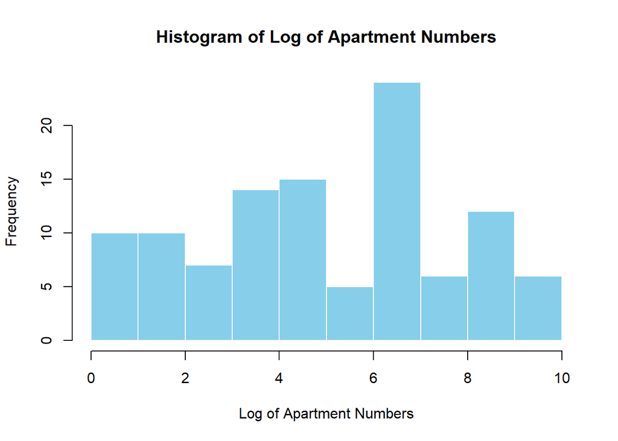

```r
# Extract the address column from the dataset
addresses <- us_records$address

# Use regex to extract apartment numbers that appear after a '#' symbol
# If the address contains a '#', extract the number following it; otherwise, return NA
apartment_numbers_raw <- ifelse(grepl("#\\d+$", addresses), sub(".*#(\\d+)$", "\\1", addresses), NA)

# Convert the extracted apartment numbers to numeric values
# Any non-numeric or missing apartment numbers will be converted to NA
apartment_numbers <- as.numeric(apartment_numbers_raw)

# Remove any NA values (addresses without apartment numbers or invalid extractions)
# na.omit() will drop these NAs from the dataset
apartment_numbers <- na.omit(apartment_numbers)

# Apply a log transformation to the apartment numbers to reduce skewness and prepare for histogram plotting
log_apartment_numbers <- log(apartment_numbers)

# Create a histogram of the log-transformed apartment numbers
# This histogram helps visualize the distribution of apartment numbers on a log scale
hist(log_apartment_numbers, main = "Histogram of Log of Apartment Numbers",
     xlab = "Log of Apartment Numbers", col = "skyblue", border = "white", breaks = 10)
```

### (e) Benford’s law

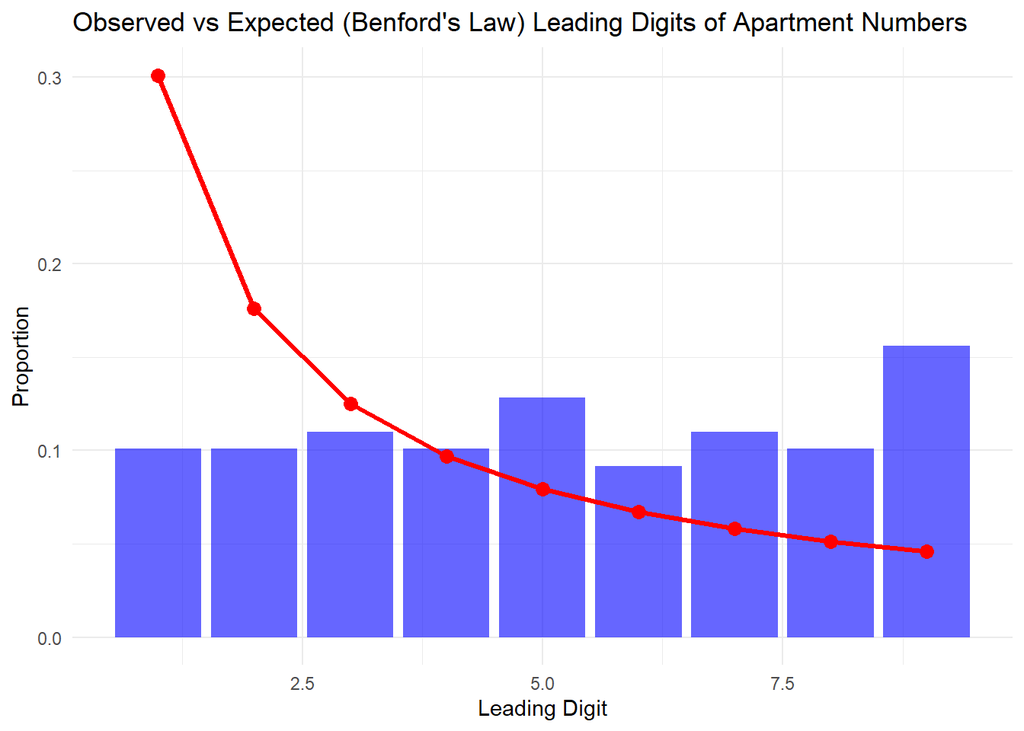

```r
# Remove any NA values from the apartment numbers dataset to ensure clean data
apartment_numbers <- na.omit(apartment_numbers)

# Extract the leading digit from each apartment number by converting to a string
# substr() is used to grab the first character, then we convert it back to numeric
leading_digits <- as.numeric(substr(as.character(apartment_numbers), 1, 1))

# Count the frequency of each leading digit and calculate the proportion of occurrences
# table() creates a frequency table, and we divide by the total number of apartment numbers to get proportions
observed_distribution <- table(leading_digits) / length(leading_digits)

# Calculate the expected distribution based on Benford's Law
# Benford's Law predicts the frequency of leading digits using the formula log10(1 + 1/digit)
benford_law <- log10(1 + 1 / (1:9))

# Create a data frame to compare the observed and expected leading digit distributions
comparison_df <- data.frame(
  Digit = 1:9,  # The digits 1 through 9
  Observed = as.numeric(observed_distribution),  # The observed proportions of each digit
  Expected = benford_law  # The expected proportions based on Benford's Law
)

# Plot the observed and expected distributions using ggplot2
# We use bars for the observed proportions and a line/points for the expected values from Benford's Law
library(ggplot2)
ggplot(comparison_df, aes(x = Digit)) +
  geom_bar(aes(y = Observed), stat = "identity", fill = "blue", alpha = 0.6) +  # Blue bars for observed data
  geom_line(aes(y = Expected), color = "red", linewidth = 1.2) +  # Red line for expected Benford's distribution
  geom_point(aes(y = Expected), color = "red", size = 3) +  # Red points to highlight the expected values
  labs(title = "Observed vs Expected (Benford's Law) Leading Digits of Apartment Numbers",
       x = "Leading Digit", y = "Proportion") +  # Custom labels for the plot
  theme_minimal()  # Minimal theme for a clean look
```

The apartment numbers don’t seem to follow Benford’s Law, which predicts that lower digits like 1 should appear more frequently as the first digit. In this data, the leading digits are more evenly spread, with spikes at 5 and 9, which is not what Benford’s Law suggests. This makes sense because this dataset is fake, it’s not real-world data, and could have been randomly generated or assigned in a way that doesn’t reflect natural patterns. So, they likely wouldn’t pass as real data.